# Clase 5: Web Scraping

Transfermarkt + Wikipedia — ¿El dinero predice el éxito en el Mundial?

Introducción a la Programación para Economistas

2026-07-02

```r
library(tidyverse)
library(rvest)
library(polite)
library(broom)
library(patchwork)
```

# ¿Qué es web scraping?

Cuando abres una página web, tu navegador hace lo siguiente:

1. **Manda una petición** al servidor: “dame el contenido de esta URL”
2. El servidor **responde** con un archivo de texto en formato **HTML**
3. El navegador **interpreta** ese HTML y lo convierte en la página visual que ves

**Web scraping** es el paso 2 sin el paso 3: leemos ese HTML directamente desde R y extraemos los datos que nos interesan — sin copiar y pegar a mano.

La diferencia con una **API**: una API es un servicio que el sitio ofrece explícitamente para dar datos estructurados. El scraping lee el HTML que estaba pensado para un navegador. Las APIs son más estables; el scraping es más flexible pero más frágil — si el sitio cambia su diseño, el código puede romperse.

# Buenas prácticas antes de scrapear

Antes de scrapear cualquier sitio hay que revisar su archivo `robots.txt` — un archivo que los sitios publican para indicar qué partes pueden ser accedidas por bots y a qué velocidad.

El paquete `polite` hace esto automáticamente: revisa el `robots.txt`, se presenta con un User-Agent de navegador (sin esto muchos sitios bloquean la petición), y respeta los tiempos de espera indicados.

```r
# install.packages("polite")
library(polite)

# bow() se "presenta" ante el sitio y revisa el robots.txt
sesion <- bow("https://www.transfermarkt.es",
              user_agent = "Mozilla/5.0 (compatible; estudiante/1.0)")

sesion
```

Y siempre hay que guardar los datos después de scrapear:

```r
# guardar una vez
write_csv(mis_datos, "datos/datos_crudos.csv")

# en futuras sesiones leer del disco — no volver a scrapear
mis_datos <- read_csv("datos/datos_crudos.csv")
```

# La pregunta

¿El valor de mercado de una selección predice cuántos puntos saca en la fase de grupos del Mundial?

Para responderla necesitamos dos fuentes:

- **Transfermarkt**: valor de mercado, edad promedio y experiencia de cada selección
- **Wikipedia**: puntos reales obtenidos en la fase de grupos del Mundial 2026

# Parte 1: Scraping de Transfermarkt

## Cómo identificar qué tabla queremos

Antes de escribir código, hay que inspeccionar la página. En Chrome:

1. Ve a la página que quieres scrapear
2. Clic derecho sobre la tabla → **Inspeccionar**
3. En el panel de HTML, busca el tag `<table>` y su atributo `class`

En Transfermarkt, las tablas usan la clase CSS `items`. Eso es lo que le decimos a `rvest`.

```r
url_tm <- "https://www.transfermarkt.es/weltmeisterschaft/teilnehmer/pokalwettbewerb/FIWC/saison_id/2025"

# polite descarga el HTML respetando el robots.txt
sesion <- bow(url_tm, user_agent = "Mozilla/5.0 (compatible; estudiante/1.0)")
pagina <- scrape(sesion)

# html_elements("table.items") selecciona todas las tablas con clase "items"
# html_table() convierte cada tabla HTML en un data frame de R
tablas <- pagina %>%
  html_elements("table.items") %>%
  html_table()

# la página tiene tres tablas — una por grupo de selecciones
length(tablas)
```

```
## [1] 3
```

```r
# veamos los nombres de columnas de la primera tabla
# janitor::clean_names() los convierte a formato manejable (sin espacios, sin acentos)
tablas[[1]] %>%
  janitor::clean_names() %>%
  names()
```

```
## [1] "wappen"             "club"               "club_2"
## [4] "plantilla"          "o_edad"             "participaciones"
## [7] "en_el_extranjero"   "valor_de_mercado"   "o_valor_de_mercado"
```

```r
# veamos la primera fila para confirmar qué tiene cada columna
tablas[[1]] %>%
  janitor::clean_names() %>%
  .[1, ]
```

```
## # A tibble: 1 × 9
##   wappen club    club_2 plantilla o_edad participaciones en_el_extranjero
##   <lgl>  <chr>    <int> <chr>      <int> <chr>           <chr>
## 1 NA     Francia     26 27,1          17 73,1 %          1,52 mil mill. €
## # ℹ 2 more variables: valor_de_mercado <chr>, o_valor_de_mercado <lgl>
```

```r
limpiar_tabla_tm <- function(tabla) {
  tabla %>%
    janitor::clean_names() %>%
    select(
      pais            = club,       # character — nombre del país
      plantilla       = club_2,     # integer — tamaño de plantilla (26)
      edad_promedio   = plantilla,
      participaciones = o_edad,
      extranjero      = participaciones,
      valor_mercado   = en_el_extranjero,
      valor_promedio  = valor_de_mercado
    ) %>%
    mutate(pais = as.character(pais)) %>%
    filter(!is.na(pais), pais != "Club")
}

tabla1 <- limpiar_tabla_tm(tablas[[1]])
tabla2 <- limpiar_tabla_tm(tablas[[2]])

# unimos las dos tablas — bind_rows al final para que los nombres ya estén limpios
mundial_2026 <- bind_rows(tabla1, tabla2)

head(mundial_2026, 5)
```

```
## # A tibble: 5 × 7
##   pais       plantilla edad_promedio participaciones extranjero valor_mercado
##   <chr>          <int> <chr>                   <int> <chr>      <chr>
## 1 Francia           26 27,1                       17 73,1 %     1,52 mil mill. €
## 2 Inglaterra        26 27,4                       17 23,1 %     1,36 mil mill. €
## 3 España            26 26,8                       18 30,8 %     1,22 mil mill. €
## 4 Portugal          26 28,1                       10 80,8 %     1,01 mil mill. €
## 5 Alemania          26 28,1                       21 30,8 %     947,00 mill. €
## # ℹ 1 more variable: valor_promedio <chr>
```

## Limpiar formatos

Los valores de mercado vienen como texto (`"1,52 mil mill. €"`) — hay que convertirlos a números. El truco es detectar si dice “mil mill.” o solo “mill.” para saber si hay que multiplicar por 1000:

```r
# ── Limpiar formatos ──────────────────────────────────────────────────────────

# Los datos de Transfermarkt vienen como texto, no como números.
# Antes de poder hacer cualquier cálculo hay que convertirlos.
# Usamos mutate() para modificar varias columnas a la vez.

mundial_2026 <- mundial_2026 %>%
  mutate(

    # ── edad_promedio ──────────────────────────────────────────────────────────
    # viene como "27,1" — Europa usa coma como separador decimal, no punto
    # str_replace(x, ",", ".") cambia la coma por punto: "27,1" → "27.1"
    # as.numeric() convierte el texto a número: "27.1" → 27.1
    edad_promedio = str_replace(edad_promedio, ",", ".") %>%
                    as.numeric(),

    # ── extranjero ─────────────────────────────────────────────────────────────
    # viene como "73,1 %" — hay que quitar el símbolo % y la coma decimal
    # paso 1: str_remove(x, " %") quita " %" del texto: "73,1 %" → "73,1"
    # paso 2: str_replace(x, ",", ".") cambia la coma: "73,1" → "73.1"
    # paso 3: as.numeric() convierte a número: "73.1" → 73.1
    extranjero = str_remove(extranjero, " %") %>%
                 str_replace(",", ".") %>%
                 as.numeric(),

    # ── valor_mercado ──────────────────────────────────────────────────────────
    # este es el más complicado porque viene en tres formatos distintos:
    #   "1,52 mil mill. €"  → 1,520 millones  (miles de millones)
    #   "947,00 mill. €"    → 947 millones
    #
    # usamos case_when() — funciona como un if/else pero para vectores:
    # evalúa cada fila y aplica la fórmula del primer caso que se cumpla
    #
    # str_detect(x, "texto") devuelve TRUE si "texto" aparece en x
    # str_extract(x, "[\\d,]+") extrae solo los dígitos y comas del texto
    #   por ejemplo: "1,52 mil mill. €" → "1,52"
    #   [\\d,]+ significa: uno o más caracteres que sean dígito (\\d) o coma (,)

    valor_mercado = case_when(

      # caso 1: contiene "mil mill" → son miles de millones
      # extraemos el número, cambiamos coma por punto, y multiplicamos por 1000
      # "1,52 mil mill. €" → "1,52" → "1.52" → 1.52 → 1520 millones
      str_detect(valor_mercado, "mil mill") ~
        str_extract(valor_mercado, "[\\d,]+") %>%
        str_replace(",", ".") %>%
        as.numeric() * 1000,

      # caso 2: contiene "mill" (pero NO "mil mill", porque ese ya se atrapó arriba)
      # extraemos el número y convertimos directamente a millones
      # "947,00 mill. €" → "947,00" → "947.00" → 947 millones
      str_detect(valor_mercado, "mill") ~
        str_extract(valor_mercado, "[\\d,]+") %>%
        str_replace(",", ".") %>%
        as.numeric(),

      # caso 3 (TRUE): cualquier otra cosa → NA
      # TRUE funciona como el "else" final — atrapa todo lo que no coincidió arriba
      TRUE ~ NA_real_
    ),

    # ── valor_promedio ─────────────────────────────────────────────────────────
    # mismo problema que valor_mercado, pero con un tercer formato:
    #   "991 mil €" → son miles de euros, no millones
    #   hay que dividir entre 1000 para convertir a millones

    valor_promedio = case_when(

      str_detect(valor_promedio, "mil mill") ~
        str_extract(valor_promedio, "[\\d,]+") %>%
        str_replace(",", ".") %>%
        as.numeric() * 1000,

      str_detect(valor_promedio, "mill") ~
        str_extract(valor_promedio, "[\\d,]+") %>%
        str_replace(",", ".") %>%
        as.numeric(),

      # caso nuevo: "991 mil €" → miles de euros → dividimos entre 1000
      # "991 mil €" → "991" → 991 → 991/1000 → 0.991 millones
      str_detect(valor_promedio, "mil €") ~
        str_extract(valor_promedio, "[\\d,]+") %>%
        str_replace(",", ".") %>%
        as.numeric() / 1000,

      TRUE ~ NA_real_
    )
  )

head(mundial_2026,5)
```

```
## # A tibble: 5 × 7
##   pais       plantilla edad_promedio participaciones extranjero valor_mercado
##   <chr>          <int>         <dbl>           <int>      <dbl>         <dbl>
## 1 Francia           26          27.1              17       73.1          1520
## 2 Inglaterra        26          27.4              17       23.1          1360
## 3 España            26          26.8              18       30.8          1220
## 4 Portugal          26          28.1              10       80.8          1010
## 5 Alemania          26          28.1              21       30.8           947
## # ℹ 1 more variable: valor_promedio <dbl>
```

# Parte 2: Scraping de Wikipedia

## Identificar las tablas correctas

Wikipedia es más sencilla de scrapear que Transfermarkt porque no bloquea bots. Usamos `read_html()` directamente.

Primero inspeccionamos cuántas tablas hay y cuáles tienen la columna `Pts`:

```r
# ── Scrapear Wikipedia ────────────────────────────────────────────────────────

# read_html() descarga el HTML completo de la página y lo guarda en un objeto
# es como cuando tu navegador "abre" la página, pero en vez de mostrártela
# visualmente, R la guarda como texto para que podamos extraer datos de ella
pagina_wiki <- read_html(
  "https://es.wikipedia.org/wiki/Copa_Mundial_de_F%C3%BAtbol_de_2026"
)

# html_elements("table") busca todos los tags <table> en el HTML
# html_table() convierte cada tabla HTML en un data frame de R
# el resultado es una lista — cada elemento de la lista es una tabla distinta
todas_tablas <- pagina_wiki %>%
  html_elements("table") %>%
  html_table()

# una página de Wikipedia puede tener decenas de tablas
# (infoboxes, tablas de navegación, tablas de datos, etc.)
# necesitamos identificar cuáles son las tablas de grupos
# las tablas de grupos tienen una columna llamada exactamente "Pts"

# seq_along(todas_tablas) genera la secuencia 1, 2, 3, ..., n
# donde n es el número total de tablas — equivale a 1:length(todas_tablas)
# usamos un for loop para revisar cada tabla una por una

for (i in seq_along(todas_tablas)) {

  # colnames() devuelve los nombres de las columnas de la tabla i
  cols <- colnames(todas_tablas[[i]])

  # any() devuelve TRUE si AL MENOS UNO de los elementos es TRUE
  # str_detect(cols, "^Pts$") revisa si algún nombre de columna es exactamente "Pts"
  #   ^ significa "empieza con"
  #   $ significa "termina con"
  #   juntos, "^Pts$" significa "exactamente Pts" — no "Puntos", no "Pts acumulados"
  if (any(str_detect(cols, "^Pts$"))) {

    # cat() imprime texto en la consola
    # paste(cols, collapse = ", ") une todos los nombres de columnas con ", "
    # así vemos: "Tabla 15 : Selección, Pts, PJ, PG, PE, PP, GF, GC, Dif"
    cat("Tabla", i, ":", paste(cols, collapse = ", "), "\n")
  }
}
```

```
## Tabla 15 : Selección, Pts, PJ, PG, PE, PP, GF, GC, Dif
## Tabla 22 : Selección, Pts, PJ, PG, PE, PP, GF, GC, Dif
## Tabla 29 : Selección, Pts, PJ, PG, PE, PP, GF, GC, Dif
## Tabla 36 : Selección, Pts, PJ, PG, PE, PP, GF, GC, Dif
## Tabla 43 : Selección, Pts, PJ, PG, PE, PP, GF, GC, Dif
## Tabla 50 : Selección, Pts, PJ, PG, PE, PP, GF, GC, Dif
## Tabla 57 : Selección, Pts, PJ, PG, PE, PP, GF, GC, Dif
## Tabla 64 : Selección, Pts, PJ, PG, PE, PP, GF, GC, Dif
## Tabla 71 : Selección, Pts, PJ, PG, PE, PP, GF, GC, Dif
## Tabla 78 : Selección, Pts, PJ, PG, PE, PP, GF, GC, Dif
## Tabla 85 : Selección, Pts, PJ, PG, PE, PP, GF, GC, Dif
## Tabla 92 : Selección, Pts, PJ, PG, PE, PP, GF, GC, Dif
## Tabla 99 : Equipo, Gr, Pts, PJ, PG, PE, PP, GF, GC, Dif
```

```r
# el output nos dice que las tablas de grupos están en los índices
# 15, 22, 29, 36... — cada 7 posiciones, una por cada grupo (A hasta L)
```

Las tablas de grupos aparecen en los índices 15, 22, 29… cada 7 posiciones — una por cada uno de los 12 grupos del Mundial 2026. La tabla 99 es el clasificación general.

```r
# ya sabemos que las tablas de grupos están en las posiciones 15, 22, 29...
# en vez de extraerlas una por una (tabla 15, tabla 22, tabla 29...),
# creamos una secuencia con seq() para automatizarlo

# seq(15, 92, by = 7) genera: 15, 22, 29, 36, 43, 50, 57, 64, 71, 78, 85, 92
# son exactamente 12 números — uno por cada grupo del Mundial 2026
indices_grupos <- seq(15, 92, by = 7)

# LETTERS es un vector que ya viene en R con las 26 letras del abecedario
# LETTERS[1:12] toma las primeras 12: "A", "B", "C", ..., "L"
grupos <- LETTERS[1:12]

# ── map2_dfr ──────────────────────────────────────────────────────────────────
# map2_dfr es del paquete purrr (parte del tidyverse)
# hace dos cosas a la vez:
# 1. itera sobre DOS vectores en paralelo (indices_grupos y grupos)
# 2. combina todos los resultados en un solo data frame (eso es el "_dfr")
#
# en cada iteración recibe dos valores:
#   idx   = el índice de la tabla (15, 22, 29...)
#   letra = la letra del grupo ("A", "B", "C"...)
#
# es equivalente a hacer esto a mano pero para los 12 grupos:
#   grupo_a <- todas_tablas[[15]] %>% mutate(grupo = "Grupo A")
#   grupo_b <- todas_tablas[[22]] %>% mutate(grupo = "Grupo B")
#   ...
#   bind_rows(grupo_a, grupo_b, ...)

fase_grupos <- map2_dfr(indices_grupos, grupos, function(idx, letra) {

  todas_tablas[[idx]] %>%

    # mutate agrega una columna nueva a cada tabla
    # paste0("Grupo ", letra) pega "Grupo " con la letra: "Grupo A", "Grupo B"...
    # así cuando unamos las 12 tablas sabemos de qué grupo es cada fila
    mutate(grupo = paste0("Grupo ", letra))
})

head(fase_grupos, 5)
```

```
## # A tibble: 5 × 10
##   Selección             Pts    PJ    PG    PE    PP    GF    GC Dif   grupo
##   <chr>               <int> <int> <int> <int> <int> <int> <int> <chr> <chr>
## 1 MEX México              9     3     3     0     0     6     0 6     Grupo A
## 2 RSA Sudáfrica           4     3     1     1     1     2     3 –1    Grupo A
## 3 KOR Corea del Sur       3     3     1     0     2     2     3 –1    Grupo A
## 4 CZE República Checa     1     3     0     1     2     2     6 –4    Grupo A
## 5 SUI Suiza               7     3     2     1     0     7     3 4     Grupo B
```

```r
# 48 filas en total — 4 selecciones × 12 grupos
```

## Limpiar la columna de país

La columna `Selección` viene con el código FIFA adelante (`"MEX México"`). Usamos `substr` para cortar los primeros 4 caracteres (3 letras + 1 espacio):

```r
fase_grupos <- fase_grupos %>%
  mutate(
    # substr(x, 5, nchar(x)) corta los primeros 4 caracteres (el código FIFA + espacio)
    # "MEX México" → "México",  "ARG Argentina" → "Argentina"
    pais = substr(Selección, 5, nchar(Selección)),

    # algunos nombres difieren entre TM y Wikipedia — los igualamos a mano
    # si no, el join no va a encontrar la pareja y perdemos esas filas
    pais = case_when(
      pais == "República Checa"      ~ "Chequia",
      pais == "Bosnia y Herzegovina" ~ "Bosnia-Herzegovina",
      pais == "R. D. del Congo"      ~ "República Democrática del Congo",
      TRUE                           ~ pais
    ),

    # Dif viene con guión tipográfico "–" en vez de "-"
    # R no lo reconoce como negativo hasta que lo reemplazamos
    Dif = str_replace(Dif, "–", "-") %>% as.integer()
  ) %>%
  select(-Selección)   # ya no necesitamos la columna original

# anti_join devuelve los países que NO tienen pareja en la otra tabla
# character(0) en ambos significa que todos coinciden — podemos hacer el join
anti_join(fase_grupos, mundial_2026, by = "pais") %>% pull(pais)
```

```
## character(0)
```

```r
anti_join(mundial_2026, fase_grupos, by = "pais") %>% pull(pais)
```

```
## character(0)
```

`character(0)` en ambos significa que todos los países coinciden — podemos hacer el join.

# Parte 3: Unir las dos fuentes

```r
datos_modelo <- mundial_2026 %>%
  left_join(fase_grupos, by = "pais")

head(datos_modelo,5)
```

```
## # A tibble: 5 × 16
##   pais       plantilla edad_promedio participaciones extranjero valor_mercado
##   <chr>          <int>         <dbl>           <int>      <dbl>         <dbl>
## 1 Francia           26          27.1              17       73.1          1520
## 2 Inglaterra        26          27.4              17       23.1          1360
## 3 España            26          26.8              18       30.8          1220
## 4 Portugal          26          28.1              10       80.8          1010
## 5 Alemania          26          28.1              21       30.8           947
## # ℹ 10 more variables: valor_promedio <dbl>, Pts <int>, PJ <int>, PG <int>,
## #   PE <int>, PP <int>, GF <int>, GC <int>, Dif <int>, grupo <chr>
```

48 filas — una por selección. Tenemos las variables de Transfermarkt y los resultados de Wikipedia en un solo data frame.

# Parte 4: Transformaciones antes de modelar

Antes de estimar, construimos variables más informativas:

```r
datos_modelo <- datos_modelo %>%
  mutate(
    # log del valor de mercado — la relación con puntos es probablemente no lineal
    # el salto de 100 a 200 millones importa más que el de 1000 a 1100
    log_valor = log(valor_mercado),

    # log de participaciones — mismo argumento
    # +1 para evitar log(0) en selecciones en su primer Mundial
    log_part  = log(participaciones + 1)
  ) %>%
  group_by(grupo) %>%
  mutate(
    # fortaleza de rivales: valor de mercado promedio de los otros tres equipos del grupo
    # (suma del grupo - valor propio) / 3
    fortaleza_rivales = (sum(valor_mercado) - valor_mercado) / 3
  ) %>%
  ungroup()
```

# Parte 5: El modelo

```r
modelo <- lm(Pts ~ log_valor + log_part + extranjero + fortaleza_rivales,
             data = datos_modelo)

summary(modelo)
```

```
##
## Call:
## lm(formula = Pts ~ log_valor + log_part + extranjero + fortaleza_rivales,
##     data = datos_modelo)
##
## Residuals:
##     Min      1Q  Median      3Q     Max
## -3.5854 -0.9222  0.0893  1.0666  3.6291
##
## Coefficients:
##                    Estimate Std. Error t value Pr(>|t|)
## (Intercept)       -3.228308   1.262465  -2.557 0.014164 *
## log_valor          1.095198   0.265163   4.130 0.000164 ***
## log_part           0.931776   0.441096   2.112 0.040497 *
## extranjero         0.006988   0.008896   0.785 0.436474
## fortaleza_rivales -0.002211   0.001438  -1.537 0.131516
## ---
## Signif. codes:  0 '***' 0.001 '**' 0.01 '*' 0.05 '.' 0.1 ' ' 1
##
## Residual standard error: 1.53 on 43 degrees of freedom
## Multiple R-squared:  0.6729, Adjusted R-squared:  0.6425
## F-statistic: 22.12 on 4 and 43 DF,  p-value: 5.674e-10
```

El R² ajustado de 0.64 significa que el modelo explica el 64% de la variación en puntos — bastante bien para un modelo tan sencillo.

La fortaleza de los rivales tiene el signo correcto (negativo) pero no es estadísticamente significativa — en un torneo de 48 equipos con grupos de 4, la variación en la dificultad del grupo no es tan grande.

# Parte 6: Visualizaciones

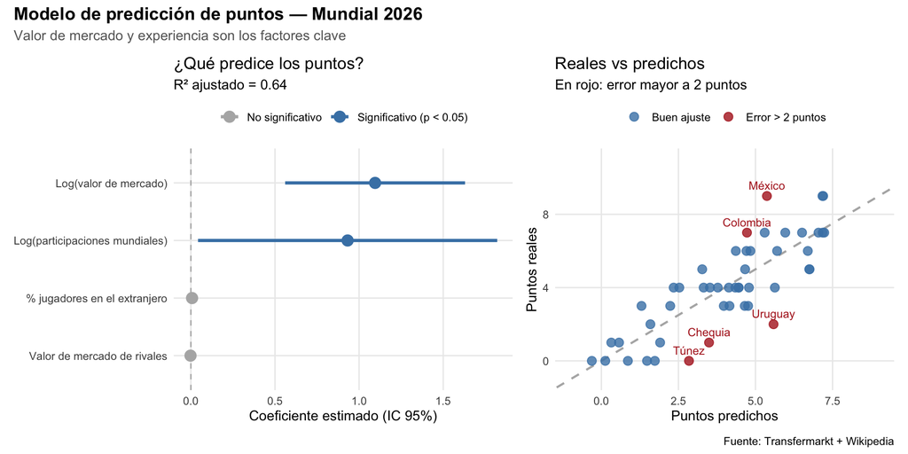

```r
# corregir acento si es necesario
datos_modelo <- datos_modelo %>%
  mutate(pais = str_replace(pais, "^Mexico$", "México"))

# ── Coeficiente plot ──────────────────────────────────────────────────────────

p_coef <- tidy(modelo, conf.int = TRUE) %>%
  filter(term != "(Intercept)") %>%
  mutate(
    term = recode(term,
      "log_valor"         = "Log(valor de mercado)",
      "log_part"          = "Log(participaciones mundiales)",
      "extranjero"        = "% jugadores en el extranjero",
      "fortaleza_rivales" = "Valor de mercado de rivales"
    ),
    significativo = p.value < 0.05
  ) %>%
  ggplot(aes(x = estimate, y = reorder(term, estimate),
             xmin = conf.low, xmax = conf.high,
             color = significativo)) +
  geom_vline(xintercept = 0, linetype = "dashed", color = "gray70") +
  geom_pointrange(linewidth = 1.2, size = 0.8) +
  scale_color_manual(
    values = c("TRUE" = "steelblue", "FALSE" = "gray70"),
    labels = c("TRUE" = "Significativo (p < 0.05)",
               "FALSE" = "No significativo")
  ) +
  labs(
    title    = "¿Qué predice los puntos?",
    subtitle = "R² ajustado = 0.64",
    x        = "Coeficiente estimado (IC 95%)",
    y        = NULL,
    color    = NULL
  ) +
  theme_minimal() +
  theme(legend.position = "top", panel.grid.minor = element_blank())

# ── Valores ajustados vs reales ───────────────────────────────────────────────

datos_aug <- augment(modelo) %>%
  mutate(pais = datos_modelo$pais)

errores_grandes <- datos_aug %>% filter(abs(.resid) > 2)

p_fit <- datos_aug %>%
  ggplot(aes(x = .fitted, y = Pts)) +
  geom_abline(slope = 1, intercept = 0,
              color = "gray70", linetype = "dashed", linewidth = 0.8) +
  geom_point(aes(color = abs(.resid) > 2), size = 3, alpha = 0.8) +
  geom_text(data = errores_grandes,
            aes(x = .fitted, y = Pts, label = pais),
            size = 3.2, vjust = -0.8, color = "firebrick") +
  scale_color_manual(
    values = c("TRUE" = "firebrick", "FALSE" = "steelblue"),
    labels = c("TRUE" = "Error > 2 puntos", "FALSE" = "Buen ajuste")
  ) +
  scale_y_continuous(limits = c(-1, 11)) +
  scale_x_continuous(limits = c(-1, 9)) +
  labs(
    title    = "Reales vs predichos",
    subtitle = "En rojo: error mayor a 2 puntos",
    x        = "Puntos predichos",
    y        = "Puntos reales",
    color    = NULL
  ) +
  theme_minimal() +
  theme(legend.position = "top", panel.grid.minor = element_blank())

# ── Combinar ──────────────────────────────────────────────────────────────────

p_coef + p_fit +
  plot_annotation(
    title    = "Modelo de predicción de puntos — Mundial 2026",
    subtitle = "Valor de mercado y experiencia son los factores clave",
    caption  = "Fuente: Transfermarkt + Wikipedia",
    theme    = theme(
      plot.title    = element_text(size = 14, face = "bold"),
      plot.subtitle = element_text(size = 11, color = "gray40")
    )
  )
```